# CFRM 502, Winter 2020

# Instructor: Bahman Angoshtari

# Lecture 15

**Chapter 13:** multivariate time series, cross-correlation matrix (CCM), multivariate Ljung-Box test, vector autoregressive (VAR) models

```r
# Setting parameters of the Jupyter notebook
sc = .75
options(repr.plot.width=16*sc,
        repr.plot.height=7*sc,
        repr.plot.pointsize = 13, # Text height in pt
        repr.plot.bg        = 'white',
        repr.plot.antialias = 'gray',
        #nice medium-res DPI
        repr.plot.res       = 300,
        #jpeg quality bumped from default
        repr.plot.quality   = 90,
        #vector font family
        repr.plot.family    = 'serif')
# Vector font family. 'sans', 'serif', 'mono' or a specific one
```

$\newcommand{\1}{{\bf 1}}$ $\newcommand{\0}{{\bf 0}}$ $\newcommand\Fc{\mathscr{F}}$ $\newcommand{\eps}{\varepsilon}$ $\newcommand{\Var}{\operatorname{Var}}$ $\newcommand{\diag}{\operatorname{diag}}$ $\newcommand{\vec}{\operatorname{vec}}$ $\newcommand{\det}{\operatorname{det}}$ $\newcommand\Cov{\operatorname{Cov}}$ $\newcommand\Corr{\operatorname{Corr}}$ $\newcommand{\sig}{\sigma}$ $\newcommand\Sig{\Sigma}$ $\newcommand{\al}{\alpha}$ $\newcommand{\gam}{\gamma}$ $\newcommand\Gam{\Gamma}$ $\newcommand\lam{\lambda}$ $\newcommand{\Del}{\Delta}$ $\newcommand{\del}{\delta}$ $\newcommand\tht{\theta}$ $\newcommand\ph{\varphi}$ $\newcommand\om{\omega}$ $\newcommand\Om{\Omega}$ $\newcommand\rb{\bar{r}}$ $\newcommand{\Xb}{\bar{X}}$ $\newcommand{\Yb}{\bar{Y}}$ $\newcommand\Eb{\mathbb{E}}$ $\newcommand\Pb{\mathbb{P}}$ $\newcommand\Qb{\mathbb{Q}}$ $\newcommand\Rb{\mathbb{R}}$ $\newcommand\Zb{\mathbb{Z}}$ $\newcommand\Nb{\mathbb{N}}$ $\newcommand\Av{\textbf{A}}$ $\newcommand\av{\mathbf{a}}$ $\newcommand\Bv{\textbf{B}}$ $\newcommand\bv{\mathbf{b}}$ $\newcommand\Ev{\textbf{E}}$ $\newcommand\Dv{\textbf{D}}$ $\newcommand\Fv{\textbf{F}}$ $\newcommand\Gv{\textbf{G}}$ $\newcommand\Hv{\textbf{H}}$ $\newcommand\Kv{\textbf{K}}$ $\newcommand\Iv{\textbf{I}}$ $\newcommand\Pv{\textbf{P}}$ $\newcommand\Ov{\textbf{O}}$ $\newcommand\Sv{\textbf{S}}$ $\newcommand\Xv{\textbf{X}}$ $\newcommand\Yv{\textbf{Y}}$ $\newcommand\Zv{\textbf{Z}}$ $\newcommand\xv{\mathbf{x}}$ $\newcommand\yv{\mathbf{y}}$ $\newcommand\zv{\mathbf{z}}$ $\newcommand\Cv{\mathbf{C}}$ $\newcommand\mv{\mathbf{m}}$ $\newcommand\nv{\mathbf{n}}$ $\newcommand\pv{\mathbf{p}}$ $\newcommand\rv{\mathbf{r}}$ $\newcommand\sv{\mathbf{s}}$ $\newcommand\wv{\mathbf{w}}$ $\newcommand\Wv{\textbf{W}}$ $\newcommand\alv{{\boldsymbol\al}}$ $\newcommand\betav{{\boldsymbol\beta}}$ $\newcommand\etav{{\boldsymbol\eta}}$ $\newcommand\epsv{{\boldsymbol\varepsilon}}$ $\newcommand\delv{{\boldsymbol\delta}}$ $\newcommand\Lamv{{\boldsymbol\Lambda}}$ $\newcommand\lamv{{\boldsymbol\lambda}}$ $\newcommand\muv{{\boldsymbol\mu}}$ $\newcommand\piv{{\boldsymbol\pi}}$ $\newcommand\Piv{{\boldsymbol\Pi}}$ $\newcommand\Gamv{{\boldsymbol\Gam}}$ $\newcommand\Phiv{{\boldsymbol\Phi}}$ $\newcommand\rhov{\boldsymbol{\rho}}$ $\newcommand\Sigv{{\boldsymbol\Sig}}$ $\newcommand\ah{\widehat{a}}$ $\newcommand\Pbh{\widehat{\Pb}}$ $\newcommand\phh{\widehat{\varphi}}$ $\newcommand\Ebh{\widehat{\Eb}}$ $\newcommand\Qh{\widehat{Q}}$ $\newcommand\Ih{\widehat{I}}$ $\newcommand\rh{\widehat{r}}$ $\newcommand\pih{\widehat{\pi}}$ $\newcommand\Pih{\widehat{\Pi}}$ $\newcommand\Sigvh{\widehat{\Sigv}}$ $\newcommand\Wh{\widehat{W}}$ $\newcommand\Fh{\widehat{F}}$ $\newcommand\Yh{\widehat{Y}}$ $\newcommand\Zh{\widehat{Z}}$ $\newcommand\Yvh{\widehat{\Yv}}$ $\newcommand\Ah{\widehat{\Ac}}$ $\newcommand\uh{\widehat{u}}$ $\newcommand\vh{\widehat{v}}$ $\newcommand\fh{\widehat{f}}$ $\newcommand\hh{\widehat{h}}$ $\newcommand\Bh{\widehat{B}}$ $\newcommand\Ovh{\widehat{\Ov}}$ $\newcommand\Xvh{\widehat{\Xv}}$ $\newcommand\rhoh{\widehat{\rho}}$ $\newcommand\omh{\widehat{\om}}$ $\newcommand\nuh{\widehat{\nu}}$ $\newcommand\varphih{\widehat{\varphi}}$ $\newcommand\alh{\widehat{\al}}$ $\newcommand\thetah{\widehat{\theta}}$ $\newcommand\betah{\widehat{\beta}}$ $\newcommand\betavh{\widehat{\boldsymbol\beta}}$ $\newcommand\kaph{\widehat{\kappa}}$ $\newcommand\sigh{\widehat{\sigma}}$ $\newcommand\epsh{\widehat{\eps}}$ $\newcommand\epsvh{\widehat{\epsv}}$ $\newcommand\epst{\widetilde{\eps}}$ $\newcommand\muh{\widehat{\mu}}$ $\newcommand\dd{\mathrm{d}}$ $\newcommand\ee{\mathrm{e}}$

# 0. Overview of the lecture

- We discuss multivariate time series modeling in this lecture.
- We first study multivariate generalizations of ACF and Ljung-Box test.
- We then learn about VAR(p) models which are the multivariate extension of univariate AR models and are among the simplest and most commonly used multivariate time series model.

# 1. Multivariate times series

- Consider a $k$ dimensional time series $\{\rv_t\} = \{(r_{t,1}, \dots, r_{t,k})^\top\}$.
- So far, we have only consider **temporal dependence** (i.e. dependence across time) for univariate time series
- In ARIMAX, we had two time series. However, we did not consider dependence of $Y_t$ on $X_{t-1}$. We only consider dependence of $Y_t$ on $X_t$
- We now turn our attention to studying multivariate time series.
- Multivariate time series models are, in general, much more complicated that univariate models, especially as the dimension of the time series increases.

## 1.1. Stationary time series

- As in the univariate case, we start by introducing the notion of **stationarity**
- **Strict stationary:** $\{\rv_t\}$ is strictly stationary if its **finite dimensional distributions** are time invariant. In other words, for any integers $m$, $t_1<t_2<\ldots<t_m$, and $T$, the joint distribution of \begin{align*} (\rv_{t_1}, \rv_{t_2}, \dots, \rv_{t_m}) \end{align*} and \begin{align*} (\rv_{t_1+T}, \rv_{t_2+T}, \dots, \rv_{t_m+T}) \end{align*} is the same.
- **Weak stationarity:** For $\{\rv_t\}$, define the first two moments as follows \begin{align*} \muv(t) = \Eb(\rv_t),\quad\text{ and }\qquad \Gamv(t,h) = \Cov(\rv_t, \rv_{t-h}). \end{align*} $\{\rv_t\}$ is weakly stationary if $\muv(t)$ and $\Gamv(t,h)$ exist and are $t$ invariant. That is, there exist a constant vector $\muv$ and a matrix function $\Gamv(h)$ such that \begin{align*} \muv(t)=\muv,\quad\text{ and }\quad \Gamv(t,h)=\Gamv(h), \end{align*} for all $t$.

## 1.2. Moments of (weakly) stationary time series

- Let $\{\rv_t\}$ be (weakly) stationary.
- The mean of $\{\rv_t\}$ is $\muv:=\Eb(\rv_t)$
- The covariance matrix of $\{\rv_t\}$ is $\Gamv_0:=\Eb\left((\rv_t-\muv)(\rv_t-\muv)^\top\right)$. Clearly, $\Gamv_0$ is symmetric. We also assume that it is of full rank. So, we assume that $\Gam_0$ is positive definite.
- What if $\Gamv_0$ is not of full rank?
- Then at least one element of $\rv_t$ can be written as a linear combination of the rest. So, we can reduce the dimension of $\{\rv_t\}$
- The lag-$h$ autocovariance matrix of $\{\rv_t\}$ is $\Gamv_h := \Eb\left((\rv_t-\muv)(\rv_{t-h}-\muv)^\top\right)$
- Note, however, that the autocovariance matrix is **NOT** symmetric!
- To see this, let us consider a stationary bivariate time series $\{\rv_t\}=\{(r_{t,1}, r_{t,2})^\top\}$
- We have

\begin{align*} \Gamv_h &= \Eb\left((\rv_t-\muv)(\rv_{t-h}-\muv)^\top\right)\\\\ &=\Eb\left(\begin{pmatrix}r_{t,1}-\mu_1\\ r_{t,2}-\mu_2\end{pmatrix}(r_{t-h,1}-\mu_1, r_{t-h,2}-\mu_2)\right)\\\\ &=\begin{pmatrix}\Eb\left(r_{t,1}-\mu_1)(r_{t-h,1}-\mu_1)\right) & \Eb\left(r_{t,1}-\mu_1)(r_{t-h,2}-\mu_2)\right)\\ \Eb\left(r_{t,2}-\mu_2)(r_{t-h,1}-\mu_1)\right) & \Eb\left(r_{t,2}-\mu_2)(r_{t-h,2}-\mu_2)\right)\end{pmatrix}\\\\ &=\begin{pmatrix}\Cov(r_{t,1}, r_{t-h,1}) & \Cov(r_{t,1}, r_{t-h,2})\\ \Cov(r_{t,2}, r_{t-h,1}) & \Cov(r_{t,2}, r_{t-h,2})\end{pmatrix} \end{align*}

- In general, $\Gamv_{h,ij} =$ $ \Cov(r_{t,i},$ $ r_{t-h,j})$
- Note that $\Gamv_{h,ij} =$ $ \Cov$ $(r_{t,i},$ $ r_{t-h,j})$ $ \ne $ $\Cov$ $(r_{t,j}, $ $r_{t-h,i}$ $) =$ $ \Gamv_{h,ji}$
- Note, however, that

\begin{align*} \Gamv_{-h,ij} &= \Cov(r_{t,i}, r_{t-(-h),j}) \\ & = \Cov(r_{t+h,j}, r_{t,i})\\ & = \Cov(r_{t,j}, r_{t-h,i})\quad\quad \text{ by stationarity}\\ & = \Gam_{-h,ji} \end{align*}

- Thus, $\Gamv_{-h} $ $= $ $\Gamv_h^\top$
- The diagonal elements of $\Gamv_h$ are $\Cov(r_{t,i}, r_{t-h,i})$. These are the lag-h autocovariance terms of the univariate time series $\{r_{t,i}\}$, $i=1,\dots,k$.
- The off-diagonal elements of $\Gamv_h$ are $\Cov(r_{t,i}, r_{t-h,j})$ for $i\ne j$. These are the **cross-covariance** between $\{r_{t,i}\}$ and $\{r_{t,j}\}$.
- To distinguish the non-symmetric aspect of $\Gamv_h$, it is usually called the **cross-covariance matrix**.
- Let $\sig_i$ be the standard deviation of $r_{t,i}$. These are the square root of diagonal elements of $\Gamv_0$.
- Define $\Dv$ $=$ $\diag($ $\sig_1,$ $\dots,$ $\sig_k)$.
- The **correlation matrix** of $\{\rv_t\}$ is \begin{align*} \rhov_0 = \Dv^{-1}\Gamv_0\Dv^{-1} \end{align*}
- The **lag-h cross-correlation matrix (CCM)** of $\{\rv_t\}$ is \begin{align*} \rhov_h = \Dv^{-1}\Gamv_h\Dv^{-1} \end{align*}
- This is the normalized version of the cross-covariance matrix, and is a generalization of the univariate auto-correlation function (ACF). $\rhov_h$ is also called the **cross-correlation function (CCF)**
- $\rho_{h,ij}$ is the correlation between $r_{t,i}$ and $r_{t-h,j}$, while $\rho_{h,ji}$ is the correlation between $r_{t,j}$ and $r_{t-h,i}$. So, $\rhov_h$, $h>0$, is not symmetric.
- We have $\rhov_{-h}$ $=$ $\rhov_h^\top$

## 1.3. Sample CCM (or CCF)

- Next, we consider estimating the first two moments of a stationary multivariate time series.
- Assume that we are given a time series $\{\rv_1,\dots, \rv_T\}$.
- The sample mean, which estimates $\muv=\Eb(\rv_t)$, is given by \begin{align*} \widehat{\muv} = \overline{\rv} := \frac{1}{T}\sum_{t=1}^T \rv_t. \end{align*}
- The sample covariance matrix, which estimates $\Gamv_0=\Cov(\rv_t)$, is given by \begin{align*} \widehat{\Gamv}_0 := \frac{1}{T-1}\sum_{t=1}^T (\rv_t-\widehat{\muv})(\rv_t-\widehat{\muv})^\top. \end{align*}
- The lag-"h" sample cross-covariance, which estimates $\Gamv_h=\Cov(\rv_t, \rv_{t-h})$, is given by \begin{align*} \widehat{\Gamv}_h := \frac{1}{T-h-1}\sum_{t=h+1}^T (\rv_t-\widehat{\muv})(\rv_{t-h}-\widehat{\muv})^\top. \end{align*}
- Finally, the lag-"h" sample CCM (or CCF), which estimates $\rhov_h=\Corr(\rv_t, \rv_{t-h})$, is given by \begin{align*} \widehat{\rhov}_h := \widehat{\Dv}^{-1}\widehat{\Gamv}_h\widehat{\Dv}^{-1},\\ ~ \end{align*} where $\widehat{\Dv}=\diag(\sqrt{\widehat{\Gamv}_{0,11}},\dots, \sqrt{\widehat{\Gamv}_{0,kk}})$ is the diagonal matrix of sample standard deviations of $\{r_{t,1},\dots,r_{t,k}\}$.

## 1.4. Multivariate Ljung-Box test

- Similar to the univariate case, we will need to check if cross-correlation is zero or not.
- The are two types of tests
- **Individual tests:** $H_0: \rhov_h=0$ versus $H_1: \rhov_l\ne 0$
- Note that the "individual tests" involves multiple parameters. So, they are a joint test!
- We refer to them as "individual" tests because they test an **individual lag**
- The test statistic is $C_h = T $ $\vec(\widehat{\rhov}_h)^\top$ $ (\widehat{\rhov}_0^{-1}$ $\otimes$ $\widehat{\rhov}_0^{-1})$ $ \vec(\widehat{\rhov}_h)$
- Under $H_0$ and the additional assumption that $\rv_1,\dots,\rv_T$ are jointly normal,, then $C_h$ is asymptotically chi-squared with $k^2$ degrees of freedom.
- Let $\Av=[\av_1,\dots, \av_n]$ be an $m\times n$ matrix with columns $\av_1,\dots, \av_n$
- We define the **stacking operator** as $\vec(\Av) = \begin{pmatrix} \av_1\\ \vdots \\ \av_n\end{pmatrix}$. That is, we stack columns of $\Av$ to form a $mn\times 1$ vector.
- **Example:**

\begin{align*} \vec\left(\left[\begin{array}{c c} 2 & 1\\ -1 & 3\end{array}\right]\right) = \begin{pmatrix}2\\-1\\1\\3\end{pmatrix} \end{align*}

- Let $\Av_{m\times n}$ and $\Bv_{\ell\times k}$ be two matrices
- The **Kronecker product** is an $m\ell\times nk$ matrix given by \begin{align*} \Av\otimes\Bv = \begin{bmatrix} a_{11}\Bv & a_{12} \Bv & \dots & a_{1n}\Bv\\ a_{21}\Bv & a_{22} \Bv & \dots & a_{2n}\Bv\\ \vdots & \vdots & \ddots & \vdots\\ a_{m1}\Bv & a_{m2} \Bv & \dots & a_{mn}\Bv \end{bmatrix} \end{align*}
- **Example:** \begin{align*} \left[\begin{array}{c c} 2 & 1\\ -1 & 3\end{array}\right]\otimes \left[\begin{array}{c c} 4 & -1 & 3\\ -2 & 5 & 2\end{array}\right] = \begin{bmatrix} 8 & -2 & 6 & 4 &-1 &3\\ -4 &10 &4 &-2 &5 &2\\-4& 1& -3 &12& -3& 9\\ 2 &-5& -2 &-6 &15 &6\end{bmatrix} \end{align*}
- Consider, again, the weekly rate changes of 1-year and 3-year treasury rates.

1. 'WGS1YR'

2. 'WGS3YR'

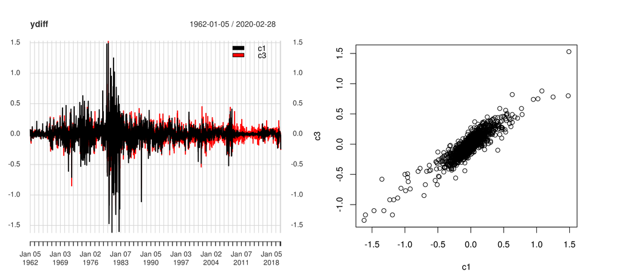

```r
library(quantmod)
getSymbols(c("WGS1YR","WGS3YR"), src="FRED", auto.assign=TRUE)
ydiff = diff(na.locf(merge(WGS1YR,WGS3YR))[index(WGS1YR)])
names(ydiff)=c('c1','c3')
c1= na.omit(as.numeric(ydiff$c1));c3=na.omit(as.numeric(ydiff$c3));
par(mfrow=c(1,2));par(mar=c(4,4,4,4))
plot(ydiff, legend.loc='topright', major.ticks = "years",
     grid.ticks.on = "years", grid.col = "lightgray")
plot(c1,c3,xlab="c1", ylab="c3")
```

- To get the sample cross correlation between any two univariate time series, use R base function `ccf()`
- Note that $\rho_{h,21}=\rho_{-h,12}$. So, we can show $\rho_{h,12}$ and $\rho_{h,21}$ in one plot!
- The individual test can be performed as in a sample ACF plot. There seems to be significant cross correlation in the bivariate time series.

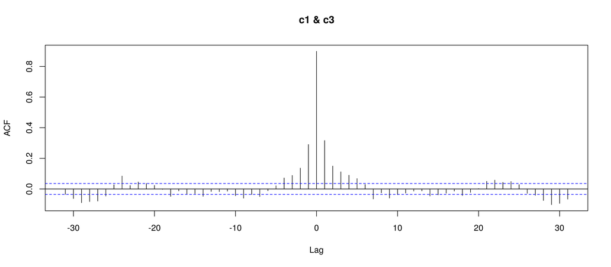

```r
ccf(c1,c3)
```

- What do the values of CCF indicate?
- Positive lags are correlation of $c1$ and lagged values of $c3$. Negative lags are correlation of $c3$ and lagged values of $c1$.
- If one passes a multivariate time series to `acf()` function, it returns the sample CCM.
- Compare the information to the CCF plot.

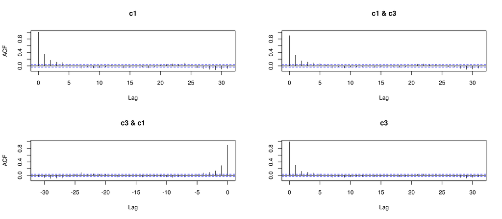

```r
acf(coredata(na.omit(ydiff)))
```

```
Ljung-Box Statistics:
       m       Q(m)     df    p-value
[1,]     1       463       4        0
[2,]     2       550       8        0
[3,]     3       593      12        0
[4,]     4       636      16        0
[5,]     5       667      20        0
```

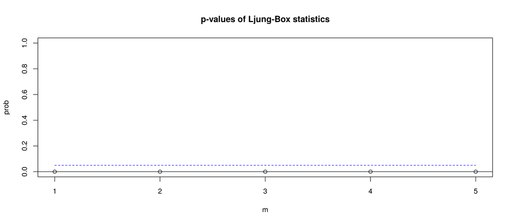

```r
library(MTS)
mq(coredata(na.omit(ydiff)), lag = 5)
```

# 2. Vector autoregressive (VAR) model

- A $k$ dimensional time series $\{\rv_t = (r_{t,1}, \dots, r_{t,k})^\top\}_{t=1}^T$ has a VAR(p) model if

\begin{align*} \begin{cases} \rv_t - \muv = \sum_{i=1}^p \Phi_i (\rv_{t-i}-\muv) + \av_t\\\\ \av_t \sim \text{weak WN}(\0_{k\times 1},\Sig_{k\times k}) \end{cases} \end{align*}

- The VAR(p) equation can be written as follows $(I_{k\times k}-\sum_{i=1}^p \Phi_i B^i)(\rv_t-\muv)=\av_t$
- Here, $I_{k\times k}$ is the identity matrix (a diagonal matrix with 1 on the diagonal) and $B$ is the lag operator: $B\rv_t=\rv_{t-1}$
- $\muv=\begin{pmatrix} \mu_1\\ \vdots\\\mu_k\end{pmatrix}$ is a constant $k$-dimensional vector
- For $i\in\{1,\dots,p\}$, the **AR coefficient matrix** $\Phi_i = \begin{bmatrix}\phi_{1,1;i} &\dots & \phi_{1,k;i}\\ \vdots & \ddots & \vdots\\ \phi_{k,1;i} &\dots &\phi_{k,k;i}\end{bmatrix}$ is a $k\times k$ constant matrix.

A time series $\{\av_{t}\}$ is a $k$-dimensional weak white noise with mean $\0$ and (instantaneous or contemporaneous) covariance matrix $\Sig$, denoted by $\av_t \sim \text{weak WN}(\0_{k\times 1},\Sig_{k\times k})$, if:

- $\av_{T}, \av_{T-1}, \dots, \av_1$ are identically distributed

\begin{align*} &\Eb(\av_t)=\0=\begin{pmatrix} 0\\ \vdots\\0\end{pmatrix}_{k\times 1}\\ &\Cov(\av_t,\av_t) = \Eb(\av_t \av_t^\top)=\Sig = \begin{bmatrix}\sig_{1,1} &\dots & \sig_{1,k}\\ \vdots & \ddots & \vdots\\ \sig_{k,1} &\dots &\sig_{k,k}\end{bmatrix} \end{align*}

- For $t\ne s$, the random vectors $\av_t$ and $\av_s$ are uncorrelated

\begin{align*} \Cov(\av_t,\av_s) = \Eb(\av_t \av_s^\top) = \0_{k\times k}=\begin{bmatrix}0 &\dots & 0\\ \vdots & \ddots & \vdots\\ 0 &\dots &0\end{bmatrix}_{k\times k}. \end{align*}

## 2.1. VAR(1) model

- For simplicity, let us only consider 2-dimensional (or bivariate) time series by assuming $k=2$
- Generalizing to $k\ge3$ is straightforward (though maybe cumbersome to write down)
- A VAR(1) model is

\begin{align*} \begin{cases} \rv_t - \muv = \Phi (\rv_{t-1}-\muv) + \av_t,\\ \av_t \sim \text{weak WN}(\0_{2\times 1},\Sig_{2\times 2}). \end{cases} \end{align*}

- Assuming $\rv_t$ is bivariate (i.e. $k=2$), the AR(1) equation has the explicit form

\begin{align*} \begin{pmatrix} r_{t,1}-\mu_1\\ r_{t,2} - \mu_2 \end{pmatrix} = \begin{bmatrix} \phi_{1,1} & \phi_{1,2}\\ \phi_{2,1} & \phi_{2,2} \end{bmatrix} \begin{pmatrix} r_{t-1,1}-\mu_1\\ r_{t-1,2} - \mu_2 \end{pmatrix} + \begin{pmatrix} a_{t,1}\\ a_{t,2} \end{pmatrix} \end{align*}

- Which, in turn, represents the following equations

\begin{align*} \begin{cases}\displaystyle r_{t,1}-\mu_1 = \phi_{1,1} (r_{t-1,1}-\mu_1) + \phi_{1,2} (r_{t-1,2}-\mu_2) + a_{t,1},\\\\ r_{t,2}-\mu_2 = \phi_{2,1} (r_{t-1,1}-\mu_1) + \phi_{2,2} (r_{t-1,2}-\mu_2) + a_{t,2}, \end{cases} \end{align*}

- $\phi_{1,1}$ represents the amount of "influence" of $r_{t-1,1}$ on $r_{t,1}$ (in the presence of $r_{t-1,2}$)
- $\phi_{1,2}$ represents the amount of "influence" of $r_{t-1,2}$ on $r_{t,1}$ (in the presence of $r_{t-1,1}$)
- Similar interpretations for $\phi_{2,1}$ and $\phi_{2,2}$.
- Consider the quarterly real gross domestic product (GDP) of Canada and US from 1980-2011

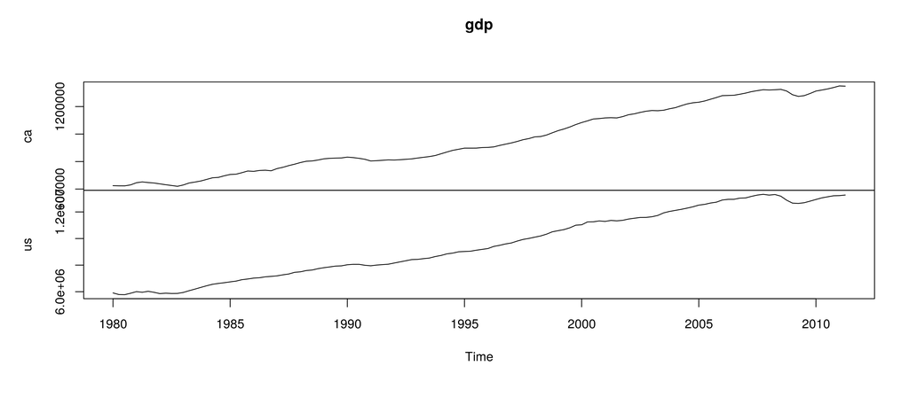

```r
da = read.table("q-ukcaus.txt", header = T)
gdp = ts(da[,4:5], start = c(1980,1), frequency = 4)
plot(gdp)
```

- Let us compute the quarterly growth rate of GDP, in percentage

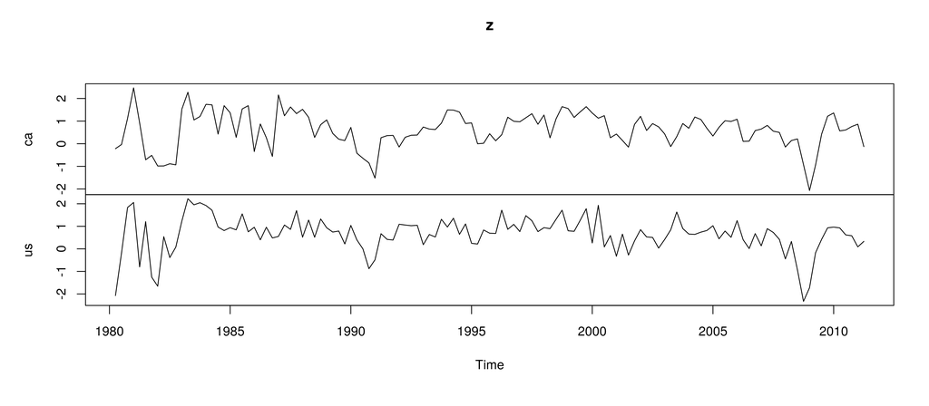

```r
z =diff(log(gdp))*100
plot(z)
```

- Next, we check if there is auto- and cross-correlation in the time series.
- The sample CCM and the multivariate Ljung-Box test indicates there is cross correlation

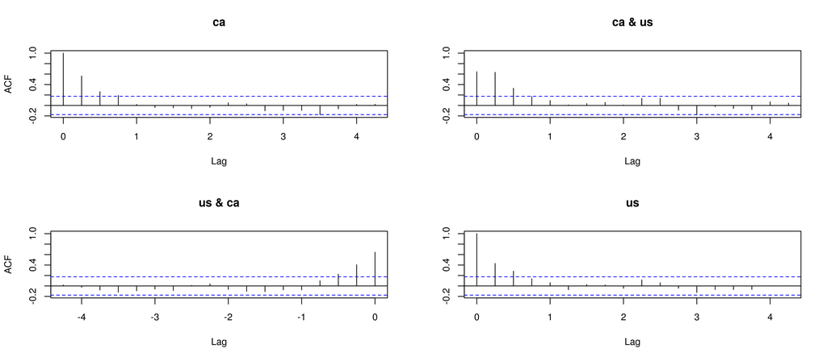

```r
acf(z)
```

```
Ljung-Box Statistics:
       m       Q(m)     df    p-value
[1,]   1.0      56.1     4.0        0
[2,]   2.0      71.6     8.0        0
[3,]   3.0      77.6    12.0        0
[4,]   4.0      82.3    16.0        0
[5,]   5.0      84.2    20.0        0
```

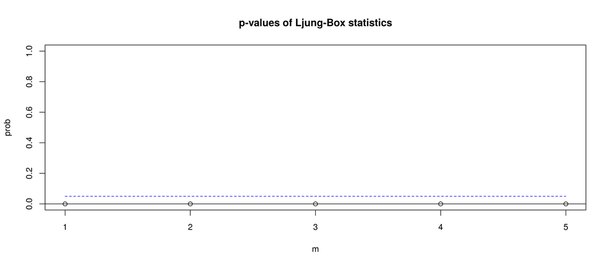

```r
mq(z, lag = 5)
```

- A VAR(1) model can be estimated using GLS (generalized least squares) or MLE.
- The estimates can be obtained in closed forms.
- We use the `VAR()` function of `MTS` package to fit a VAR(1) model.
- The fitted model is

\begin{align*} \left(I_{2\times 2} - \begin{bmatrix} 0.268 & 0.461\\ 0.222 & 0.288 \end{bmatrix} B\right) \begin{pmatrix} r_{t,CA} - 0.1559107\\ r_{t,US} - 0.3439829 \end{pmatrix} =\begin{pmatrix} a_{t,CA}\\ a_{t,US} \end{pmatrix} \end{align*}

where

\begin{align*} \begin{pmatrix} a_{t,CA}\\ a_{t,US} \end{pmatrix} \sim \text{weak WN}\left(\begin{pmatrix} 0\\ 0 \end{pmatrix}, \begin{bmatrix} 0.3372501 & 0.1904523\\ 0.1904523 & 0.4273207 \end{bmatrix}\right) \end{align*}

```r
fit_var1 = VAR(z, p=1)
```

```
Constant term:
Estimates:  0.1559107 0.3439829
Std.Error:  0.0708206 0.07971876
AR coefficient matrix
AR( 1 )-matrix
      [,1]  [,2]
[1,] 0.268 0.461
[2,] 0.222 0.288
standard error
       [,1]   [,2]
[1,] 0.0883 0.0878
[2,] 0.0994 0.0988

Residuals cov-mtx:
          [,1]      [,2]
[1,] 0.3372501 0.1904523
[2,] 0.1904523 0.4273207

det(SSE) =  0.1078419
AIC =  -2.163089
BIC =  -2.072583
HQ  =  -2.126322
```

### 2.2. Granger causality

- Consider the VAR(1) equations

\begin{align*} \begin{cases}\displaystyle r_{t,1}-\mu_1 = \phi_{1,1} (r_{t-1,1}-\mu_1) + \phi_{1,2} (r_{t-1,2}-\mu_2) + a_{t,1},\\\\ r_{t,2}-\mu_2 = \phi_{2,1} (r_{t-1,1}-\mu_1) + \phi_{2,2} (r_{t-1,2}-\mu_2) + a_{t,2}, \end{cases} \end{align*}

- Assume that $\phi_{2,1}=0$ but $\phi_{1,2}\ne0$
- Since $\phi_{2,1}=0$, then $r_{t,2}$ is **"not influenced"** by $r_{t-1,1}$ (see the equation for $r_{t,2}$)
- However, since $\phi_{1,2}\ne0$, $r_{t,1}$ is influenced by $r_{t-1,2}$
- If $\phi_{2,1}=0$ but $\phi_{1,2}\ne0$, we say that $r_2=\{r_{t,2}\}$ **causes** $r_1=\{r_{t,1}\}$
- This relationship is known as **"Granger causality"** (with $\rv_2$ causing $\rv_1$)
- It can be defined for general multivariate time series models.
- Consider univariate times series $y=\{y_t\}$ and $x=\{x_t\}$
- We say $x$ causes $y$ if information of $x_{t}, x_{t-2}, \dots$ improves forecasts of $y_{t+h}$
- Let us check if growth of US GDP causes growth of Canada GDP.
- We need to test if $\phi_{US, CA}=0$ and $\phi_{CA, US}\ne0$.
- This can be done by t-ratio tests of the coefficients

```r
names(fit_var1)
```

1. 'data'

2. 'cnst'

3. 'order'

4. 'coef'

5. 'aic'

6. 'bic'

7. 'hq'

8. 'residuals'

9. 'secoef'

10. 'Sigma'

11. 'Phi'

12. 'Ph0'

13. 'fixed'

```r
fit_var1$coef
```

A matrix: 3 × 2 of type dbl

| 0.1559107 | 0.3439829 |
| --- | --- |
| 0.2678731 | 0.2221383 |
| 0.4611597 | 0.2881903 |

```r
fit_var1$secoef
```

A matrix: 3 × 2 of type dbl

| 0.07082060 | 0.07971876 |
| --- | --- |
| 0.08829955 | 0.09939382 |
| 0.08780004 | 0.09883156 |

- We can find the t-ratios as follows

```r
t_ratios = fit_var1$coef/fit_var1$secoef
t_ratios
```

A matrix: 3 × 2 of type dbl

| 2.201488 | 4.314955 |
| --- | --- |
| 3.033686 | 2.234931 |
| 5.252385 | 2.915974 |

- The t-ratios are asymptotically normal (that is, if sample size is large)
- So, the approximate p-values of the two-sided tests are

```r
pvals = 2*pnorm(-abs(t_ratios))
colnames(pvals) = c("CA", "US")
rownames(pvals) = c("constant", "CA", "US")
round(t(pvals), digits=4)
```

A matrix: 2 × 3 of type dbl

|  | constant | CA | US |
| --- | --- | --- | --- |
| CA | 0.0277 | 0.0024 | 0.0000 |
| US | 0.0000 | 0.0254 | 0.0035 |

- Note that the off-diagonal elements of the AR matrix are significant. So, there is no Granger causality either way (US does not cause CA, CA does not cause US).

### 2.3. Stationary condition for VAR(1) model

- Consider a VAR(1) model $\rv_t - $ $\muv $ $=$ $\Phi$ $(\rv_{t-1}$ $-\muv) $ $+ \av_t$
- For any $h>0$, we have

\begin{align*} \rv_t - \muv &= \Phi (\rv_{t-1} - \muv) + \av_t\\ &= \Phi \big(\Phi(\rv_{t-2} - \muv) + \av_{t-1}\big) + \av_t\\ &= \Phi^2 (\rv_{t-2} - \muv) + \av_t + \Phi \av_{t-1}\\ &\vdots\\ &= \Phi^{t-h} (\rv_{t-h} - \muv)+ \sum_{i=0}^{t-h-1} \Phi^i \av_{t-i}. \end{align*}

- For the moment assume that the times series is defined for all negative values of $t$
- Then, if $\Phi^{t-h}\to \0_{k\times k}$ as $h\to \infty$, we obtain

\begin{align*} \rv_t - \muv = \lim_{h\to\infty}\left( \Phi^{t-h} (\rv_{t-h} - \muv)+ \sum_{i=0}^{t-h-1} \Phi^i \av_{t-i}\right) = \sum_{i=0}^{\infty} \Phi^i \av_{t-i}. \end{align*}

- Assuming that the infinite sum on the right hand side is well defined, it will be then clear that $\{r_t\}$ is weakly stationary since $\{\av_t\}$ is assumed to be a weak WN.
- Thus, $\{\rv_t\}$ is stationary if $\displaystyle\lim_{n\to\infty}\Phi^n= \0_{k\times k}$
- Recall the following facts from linear algebra for a matrix $A_{k\times k}$:
  - The eigenvalues of $A$ are the solutions $\lam$ of the determinant equation $\text{det}(\lam I_{k\times k} - A)=0$
  - $A=\0_{k\times k}$ if and only if all its eigenvalues are zero.
  - If $\{\lam_1,\dots,\lam_k\}$ are eigenvalue of $A$, then $\{\lam_1^n,\dots,\lam_k^n\}$ are eigenvalue of $A^n$
- So, $\displaystyle\lim_{n\to\infty}\Phi^n= \0_{k\times k}$ if and only if $\lim_{n\to\infty} \lam^n = 0$ for any eigenvalue $\lam$ of $\Phi$
- It then follows that $\displaystyle\lim_{n\to\infty}\Phi^n= \0_{k\times k}$ if and only if $|\lam|<1$ for all eigenvalues $\lam$ of $\Phi$
- Note that the eigenvalues of $\Phi$ are the solutions of $\det(\lam I_{k\times k} - A)=0$
- The stationary condition for VAR(1) is usually expressed in terms of the solution of the **characteristic equation** \begin{align*} \det(I_{k\times k} - x \Phi)=0 \end{align*}
- Since $\det(\lam I_{k\times k} - \Phi)= \lam^k \det\left(I_{k\times k} - \frac{1}{\lam}\Phi\right)$, the (non-zero) eigenvalues of $\Phi$ are the **inverse** of the solutions of the **characteristic equation**
- So, $|\lam|<1$ if and only if $|x|>1$.
- We obtain the stationary condition of VAR(1) model:
- VAR(1) is stationary if the absolute values of all the eigenvalues of the AR coefficient matrix $\Phi$ are less one
- Equivalently, VAR(1) is stationary if all the solutions $x$ of $\det(I_{k\times k} - x \Phi)=0$ satisfy $|x|>1$
- For $k=1$, these two conditions become the familiar stationary conditions for univariate AR(1) model:
  - AR(1) is stationary if the AR coefficient $\ph$ satisfy $|\ph|<1$
  - The solutions of the characteristic equation $1-\ph x=0$ are outside the unit circle.
- Let us check if the fitted model for US and Canada is stationary (it should be, otherwise, the estimation method is wrong)
- First, we find the AR coefficient matrix

```r
fit_var1$coef
```

A matrix: 3 × 2 of type dbl

| 0.1559107 | 0.3439829 |
| --- | --- |
| 0.2678731 | 0.2221383 |
| 0.4611597 | 0.2881903 |

```r
t(fit_var1$coef[2:3,])
```

A matrix: 2 × 2 of type dbl

| 0.2678731 | 0.4611597 |
| --- | --- |
| 0.2221383 | 0.2881903 |

- Alternatively, we can use the **companion matrix** (which we define later when discussing VAR(2) models)

```r
fit_var1$Phi
```

A matrix: 2 × 2 of type dbl

| 0.2678731 | 0.4611597 |
| --- | --- |
| 0.2221383 | 0.2881903 |

- We can use R's `eigen()` function to obtain eigenvalues of a matrix
- The eigenvalues of the companion matrix are less than 1 in absolute value, so, the VAR(1) model is stationary.

```r
eigen(fit_var1$Phi)
```

```
eigen() decomposition
$values
[1]  0.59825727 -0.04219391

$vectors
           [,1]       [,2]
[1,] -0.8129119 -0.8298618
[2,] -0.5823866  0.5579689
```

## 3. VAR(2) model

- Consider a VAR(2) model

\begin{align*} \begin{cases} \rv_t - \muv = \Phi_1 (\rv_{t-1}-\muv) + \Phi_2 (\rv_{t-2}-\muv) + \av_t,\\ \av_t \sim \text{weak WN}(\0_{2\times 1},\Sig_{2\times 2}). \end{cases} \end{align*}

- Assuming $\{\rv_t\}$ is bivariate, the VAR(2) equation is

\begin{align*} \begin{pmatrix} r_{t,1}-\mu_1\\ r_{t,2} - \mu_2 \end{pmatrix} = \begin{bmatrix} \phi_{1,1;1} & \phi_{1,2;1}\\ \phi_{2,1;1} & \phi_{2,2;1} \end{bmatrix} \begin{pmatrix} r_{t-1,1}-\mu_1\\ r_{t-1,2} - \mu_2 \end{pmatrix} +\begin{bmatrix} \phi_{1,1;2} & \phi_{1,2;2}\\ \phi_{2,1;2} & \phi_{2,2;2} \end{bmatrix} \begin{pmatrix} r_{t-1,1}-\mu_1\\ r_{t-1,2} - \mu_2 \end{pmatrix} + \begin{pmatrix} a_{t,1}\\ a_{t,2} \end{pmatrix} \end{align*}

- Which, in turn, represents the following system of equations

\begin{align*} \begin{cases}\displaystyle r_{t,1}-\mu_1 = \phi_{1,1;1} (r_{t-1,1}-\mu_1) + \phi_{1,2;1} (r_{t-1,2}-\mu_2) + \phi_{1,1;2} (r_{t-2,1}-\mu_1) + \phi_{1,2;2} (r_{t-2,2}-\mu_2) + a_{t,1},\\\\ r_{t,2}-\mu_2 = \phi_{2,1;1} (r_{t-1,1}-\mu_1) + \phi_{2,2;1} (r_{t-1,2}-\mu_2) + \phi_{2,1;2} (r_{t-2,1}-\mu_1) + \phi_{2,2;2} (r_{t-2,2}-\mu_2) + a_{t,2}.\\ \end{cases} \end{align*}

- $\phi_{1,1;1}$ represents the amount of "influence" of $r_{t-1,1}$ on $r_{t,1}$ (in the presence of $r_{t-1,2}$, $r_{t-2,1}$, and $r_{t-2,2}$)
- $\phi_{1,1;2}$ represents the amount of "influence" of $r_{t-2,1}$ on $r_{t,1}$ (in the presence of $r_{t-1,1}$, $r_{t-1,2}$, and $r_{t-2,2}$)
- In general, $\phi_{i,j;h}$ measures the amount of influence of $r_{t-h,j}$ on $r_{t,i}$ in the presence of other lagged values in $\rv_{t-1}$ and $\rv_{t-2}$
- Let us fit a VAR(2) model to US-Canada GDP growth rates.
- The fitted model is

\begin{align*} \left(I_{2\times 2} - \begin{bmatrix} 0.320 & 0.520\\ 0.212 & 0.296 \end{bmatrix} B - \begin{bmatrix} -0.118 & -0.0188\\ -0.054 & 0.0588 \end{bmatrix} B^2 \right) \begin{pmatrix} r_{t,CA} - 0.1620669\\ r_{t,US} - 0.3391791 \end{pmatrix} =\begin{pmatrix} a_{t,CA}\\ a_{t,US} \end{pmatrix} \end{align*}

where

\begin{align*} \begin{pmatrix} a_{t,CA}\\ a_{t,US} \end{pmatrix} \sim \text{weak WN}\left(\begin{pmatrix} 0\\ 0 \end{pmatrix}, \begin{bmatrix} 0.3270977 & 0.1899463\\ 0.1899463 & 0.4293033 \end{bmatrix}\right) \end{align*}

```r
fit_var2 = VAR(z, p=2)
```

```
Constant term:
Estimates:  0.1620669 0.3391791
Std.Error:  0.07587108 0.08691999
AR coefficient matrix
AR( 1 )-matrix
      [,1]  [,2]
[1,] 0.320 0.520
[2,] 0.212 0.296
standard error
      [,1]   [,2]
[1,] 0.105 0.0927
[2,] 0.120 0.1062
AR( 2 )-matrix
       [,1]    [,2]
[1,] -0.118 -0.0188
[2,] -0.054  0.0588
standard error
       [,1]   [,2]
[1,] 0.0918 0.0969
[2,] 0.1051 0.1110

Residuals cov-mtx:
          [,1]      [,2]
[1,] 0.3270977 0.1899463
[2,] 0.1899463 0.4293033

det(SSE) =  0.1043445
AIC =  -2.132057
BIC =  -1.951045
HQ  =  -2.058521
```

### 3.1. VAR(1) representation of VAR(2) model

- VAR(2) model can be seen as a higher dimensional VAR(1) model.
- For example, a 2 dimensional AR(2) process can be seen as a 4 dimensional AR(1) process.
- We show this next. First, define a new time series $\{\xv_t\}$ by stacking $\rv_{t}-\muv$ on top of $\rv_{t-1}-\muv$:

\begin{align*} \xv_t = \vec([\rv_t-\muv, \rv_{t-1}-\muv]) =\begin{pmatrix}r_{t,1}-\mu_1\\ r_{t,2}-\mu_2\\ r_{t-1,1}-\mu_1\\ r_{t-1,2}-\mu_2\end{pmatrix} \end{align*}

- We then have

\begin{align*} \xv_t &= \begin{pmatrix}\rv_t-\muv\\ \rv_{t-1}-\muv\end{pmatrix}\\\\ &= \begin{pmatrix} \Phi_1 (\rv_{t-1}-\muv) + \Phi_2 (\rv_{t-2}-\muv) + \av_t\\ I_{k\times k} (\rv_{t-1}-\muv) + \0_{k\times k} (\rv_{t-2}-\muv)\end{pmatrix}\\\\ &= \begin{bmatrix} \Phi_1 & \Phi_2 \\ I_{k\times k} & \0_{k\times k}\end{bmatrix}\begin{pmatrix}\rv_{t-1}-\muv\\ \rv_{t-2}-\muv\end{pmatrix} + \begin{pmatrix}\av_t\\ \0_{k\times 1}\end{pmatrix} \end{align*}

- Note that $\begin{pmatrix}\rv_{t-1}-\muv\\ \rv_{t-2}-\muv\end{pmatrix}$ $=$ $\xv_{t-1}$
- Let us also define $\bv_t := \begin{pmatrix}\av_t\\ \0_{k\times 1}\end{pmatrix}$ and $\Phiv$ $ := $ $\begin{bmatrix} \Phi_1 & \Phi_2 \\ I_{k\times k} & \0_{k\times k}\end{bmatrix}$
- We then have $\xv_t = \Phiv \xv_{t-1} + \bv_t$.
- So, the $2k$ dimensional time series $\{\xv_t\}$ has a VAR(1) model.
- The matrix $\Phiv := \begin{bmatrix} \Phi_1 & \Phi_2 \\ I_{k\times k} & \0_{k\times k}\end{bmatrix}$ is called the **companion Matrix** of the VAR(2) model.
- For a VAR model fitted with `VAR()` function of `MTS` package, you can get the top blocks of the companion matrix by using `$Phi`

```r
fit_var1$coef
```

A matrix: 3 × 2 of type dbl

| 0.1559107 | 0.3439829 |
| --- | --- |
| 0.2678731 | 0.2221383 |
| 0.4611597 | 0.2881903 |

```r
fit_var1$Phi
```

A matrix: 2 × 2 of type dbl

| 0.2678731 | 0.4611597 |
| --- | --- |
| 0.2221383 | 0.2881903 |

```r
fit_var2$coef
```

A matrix: 5 × 2 of type dbl

| 0.16206695 | 0.33917912 |
| --- | --- |
| 0.32007636 | 0.21191873 |
| 0.52026851 | 0.29601114 |
| -0.11797879 | -0.05398831 |
| -0.01877097 | 0.05878829 |

```r
fit_var2$Phi
```

A matrix: 2 × 4 of type dbl

| 0.3200764 | 0.5202685 | -0.11797879 | -0.01877097 |
| --- | --- | --- | --- |
| 0.2119187 | 0.2960111 | -0.05398831 | 0.05878829 |

### 3.2. Stationary conditions of VAR(2) model

- The stationary condition of VAR(2) model follows from its VAR(1) representation
- VAR(2) is stationary if all the eigenvalues of the companion matrix $\Phiv := \begin{bmatrix} \Phi_1 & \Phi_2 \\ I_{k\times k} & \0_{k\times k}\end{bmatrix}$ have absolute value less than 1.
- With a little more work, we can derive a more familiar condition.
- The characteristic equation of the VAR(1) representation is

\begin{align*} 0&=\det\left(I_{2k\times 2k} - x \Phi\right)\\ &=\det\left(\begin{bmatrix} I_{k\times k} & \0_{k\times k}\\ \0_{k\times k} & I_{k\times k} \end{bmatrix} - x \begin{bmatrix} \Phi_1 & \Phi_2 \\ I_{k\times k} & \0_{k\times k}\end{bmatrix}\right)\\ &=\det\left(\begin{bmatrix} I_{k\times k}- x \Phi_1 & - x \Phi_2 \\ -x I_{k\times k} & I_{k\times k}\end{bmatrix}\right)\\ &=\det\left(I_{k\times k} - x \Phi_1 - x^2 \Phi_2 \right) \end{align*}

- In the last step, we used the following formula for determinant of a block matrix. If $CD=DC$, then

\begin{align*} \det\left(\begin{bmatrix} A_{k\times k} & B_{k\times k}\\ C_{k\times k} & D_{k\times k} \end{bmatrix}\right) = \det\left( A D - B C\right) \end{align*}

- Finally, we obtain that the alternative stationary condition for VAR(2) process. It is stationary if all the solutions x of the following determinant equation satisfy $|x|>1$ \begin{align*} \det\left(I_{k\times k} - x \Phi_1 - x^2 \Phi_2 \right)=0. \end{align*}
- Compare this condition with the stationary condition of the AR(2) model. Recall the condition: the solutions of $1-\phi_1 x- \phi_2 x^2=0$ has absolute value greater than 1.
- Let us check if the fitted VAR(2) model of the US-Canada GDP growth rates is stationary
- We can apply the `eigen()` function to the companion matrix.
- First, we need to find the companion matrix. The top blocks are stored in `$Phi` of a fitted model with `VAR()` function.
- We only need to add $[I_{k\times k}, \0_{k\times k}]$ below it.

```r
diag(2)
```

A matrix: 2 × 2 of type dbl

| 1 | 0 |
| --- | --- |
| 0 | 1 |

```r
matrix(0L, nrow=2, ncol=2)
```

A matrix: 2 × 2 of type int

| 0 | 0 |
| --- | --- |
| 0 | 0 |

```r
cbind(diag(2), matrix(0L, nrow=2, ncol=2))
```

A matrix: 2 × 4 of type dbl

| 1 | 0 | 0 | 0 |
| --- | --- | --- | --- |
| 0 | 1 | 0 | 0 |

```r
PHI = rbind(fit_var2$Phi, cbind(diag(2), matrix(0L, nrow=2, ncol=2)))
PHI
```

A matrix: 4 × 4 of type dbl

| 0.3200764 | 0.5202685 | -0.11797879 | -0.01877097 |
| --- | --- | --- | --- |
| 0.2119187 | 0.2960111 | -0.05398831 | 0.05878829 |
| 1.0000000 | 0.0000000 | 0.00000000 | 0.00000000 |
| 0.0000000 | 1.0000000 | 0.00000000 | 0.00000000 |

```r
eigen(PHI)
```

```
eigen() decomposition
$values
[1]  0.5302632+0.0000000i  0.1545225+0.2080399i  0.1545225-0.2080399i
[4] -0.2232207+0.0000000i

$vectors
              [,1]                    [,2]                    [,3]
[1,] -0.3495396+0i -0.13913164-0.18731854i -0.13913164+0.18731854i
[2,] -0.3119151+0i -0.09082091+0.01540092i -0.09082091-0.01540092i
[3,] -0.6591813+0i -0.90039714+0.00000000i -0.90039714+0.00000000i
[4,] -0.5882270+0i -0.16126004+0.31677866i -0.16126004-0.31677866i
              [,4]
[1,]  0.1070038+0i
[2,] -0.1897702+0i
[3,] -0.4793632+0i
[4,]  0.8501461+0i
```

- We can find the absolute value of the complex eigenvalues by using `Mod()` function (recall that we used it before when checking stationarity of AR(p) models).

```r
Mod(eigen(PHI)$values)
```

1. 0.530263197380024

2. 0.259148243673112

3. 0.259148243673112

4. 0.22322073958796

- The absolute values of the eigenvalues are all less than 1. So, the fitted VAR(2) model is stationary.

# 4. VAR(p) model

- The general case if VAR(p) model is

\begin{align*} \begin{cases} \rv_t - \muv = \sum_{i=1}^p \Phi_i (\rv_{t-i}-\muv) + \av_t\\\\ \av_t \sim \text{weak WN}(\0_{k\times 1},\Sig_{k\times k}) \end{cases}\quad\quad\text{or }\quad \begin{cases} (I_{k\times k}-\sum_{i=1}^p \Phi_i B)(\rv_t-\muv)=\av_t\\\\ \av_t \sim \text{weak WN}(\0_{k\times 1},\Sig_{k\times k}) \end{cases} \end{align*}

- This model is estimated using GLS or MLE.
- Define

\begin{align*} \xv_t &=\vec([\rv_t-\muv,\dots,\rv_{t-p+1}-\muv])\\ \bv_t &=\vec([\av_t,\underbrace{\0_{k\times 1},\dots,\0_{k\times 1}}_{p-1 \text{ times }}])=\begin{pmatrix}\av_t\\ \0_{k(p-1)\times 1}\end{pmatrix} \end{align*}

- Define, also, the **"companion matrix"**

\begin{align*} \Phiv := \begin{bmatrix} \Phi_1 \dots \Phi_{p-1} & \Phi_p \\ I_{k(p-1)\times k(p-1)} & \0_{k(p-1)\times k}\end{bmatrix} \end{align*}

- The VAR(1) representation of VAR(p) is $\xv_t = \Phiv \xv_{t-1} + \bv_t$
- A $k-$dimensional VAR(p) model has a $pk$ dimensional VAR(1) representation
- VAR(p) is stationary if all the eigenvalues of the companion matrix $\Phiv$ are in the unit circle (i.e. $|\lam|<1$)
- Equivalently, Var(p) is stationary if **its characteristic equation**, defined below, does not have a unit root (i.e. $|x|>1$ for all solutions $x$) \begin{align*} \det\left(I_{k\times k} - \sum_{i=1}^p x^i \,\Phi_i \right)=0. \end{align*}

## 4.1. VAR order selection

```r
VARorder(z)
```

```
selected order: aic =  3
selected order: bic =  1
selected order: hq =  1
Summary table:
       p     AIC     BIC      HQ    M(p) p-value
 [1,]  0 -2.0304 -2.0304 -2.0304  0.0000  0.0000
 [2,]  1 -2.6140 -2.5235 -2.5772 70.2628  0.0000
 [3,]  2 -2.6024 -2.4214 -2.5289  5.5844  0.2324
 [4,]  3 -2.6230 -2.3515 -2.5127  8.8402  0.0652
 [5,]  4 -2.6213 -2.2593 -2.4742  6.3868  0.1721
 [6,]  5 -2.5757 -2.1232 -2.3918  1.8468  0.7639
 [7,]  6 -2.5287 -1.9857 -2.3081  1.6772  0.7949
 [8,]  7 -2.4905 -1.8570 -2.2332  2.4924  0.6460
 [9,]  8 -2.4581 -1.7341 -2.1640  2.9847  0.5604
[10,]  9 -2.4560 -1.6414 -2.1250  5.7198  0.2211
[11,] 10 -2.4074 -1.5023 -2.0397  1.3947  0.8451
[12,] 11 -2.4005 -1.4050 -1.9961  5.0597  0.2812
[13,] 12 -2.4061 -1.3200 -1.9649  6.0146  0.1981
[14,] 13 -2.4193 -1.2427 -1.9413  6.5265  0.1631
```

## 4.2. Model checking

- To check that the VAR(p) model is adequate, we should check its assumptions
- Specifically, we should check that the residuals are multi-dimensional weak WN
- This can be done through sample CCM and multivariate Ljung-Box test.
- The degree of freedom of the Ljung-Box test must be corrected by the number of AR parameters of the VAR(p) model (i.e. $kp$)
- Use the `MTSdiag()` function in the `MTS` package to perform model testing
- The output uses the **simplified CCM**: "$\cdot$" indicates insignificant correlation, "+" is significant positive correlation and "-" is significant negative correlation.
- We can see that the residuals are weak WN and the VAR(1) model is adequate.

```
[1] "Covariance matrix:"
      ca    us
ca 0.340 0.192
us 0.192 0.431
CCM at lag:  0
      [,1]  [,2]
[1,] 1.000 0.502
[2,] 0.502 1.000
Simplified matrix:
CCM at lag:  1
. .
. .
CCM at lag:  2
. .
. .
CCM at lag:  3
. .
. .
CCM at lag:  4
. .
. .
CCM at lag:  5
. .
. .
CCM at lag:  6
. .
. .
CCM at lag:  7
. .
. .
CCM at lag:  8
. .
. .
CCM at lag:  9
. .
. .
CCM at lag:  10
+ .
. .
CCM at lag:  11
```

[output cut: 28 more lines]

```
. .
CCM at lag:  21
. .
. .
CCM at lag:  22
. .
. .
CCM at lag:  23
. .
. .
CCM at lag:  24
. .
. .

Hit Enter for p-value plot of individual ccm:
```

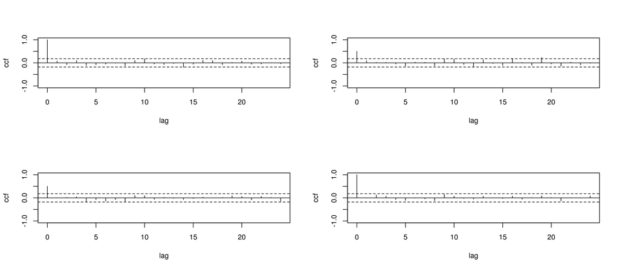

```
Hit Enter to compute MQ-statistics:
Ljung-Box Statistics:
        m       Q(m)     df    p-value
 [1,]  1.00      1.78    4.00     0.78
 [2,]  2.00      5.54    8.00     0.70
 [3,]  3.00      8.11   12.00     0.78
 [4,]  4.00     12.01   16.00     0.74
 [5,]  5.00     15.03   20.00     0.77
 [6,]  6.00     18.33   24.00     0.79
 [7,]  7.00     19.43   28.00     0.88
 [8,]  8.00     23.95   32.00     0.85
 [9,]  9.00     28.60   36.00     0.80
[10,] 10.00     34.04   40.00     0.73
[11,] 11.00     35.31   44.00     0.82
[12,] 12.00     39.99   48.00     0.79
[13,] 13.00     44.20   52.00     0.77
[14,] 14.00     50.13   56.00     0.70
[15,] 15.00     52.10   60.00     0.76
[16,] 16.00     57.34   64.00     0.71
[17,] 17.00     59.89   68.00     0.75
[18,] 18.00     62.41   72.00     0.78
[19,] 19.00     74.47   76.00     0.53
[20,] 20.00     76.97   80.00     0.58
[21,] 21.00     80.71   84.00     0.58
[22,] 22.00     83.89   88.00     0.60
[23,] 23.00     85.84   92.00     0.66
[24,] 24.00     96.32   96.00     0.47
```

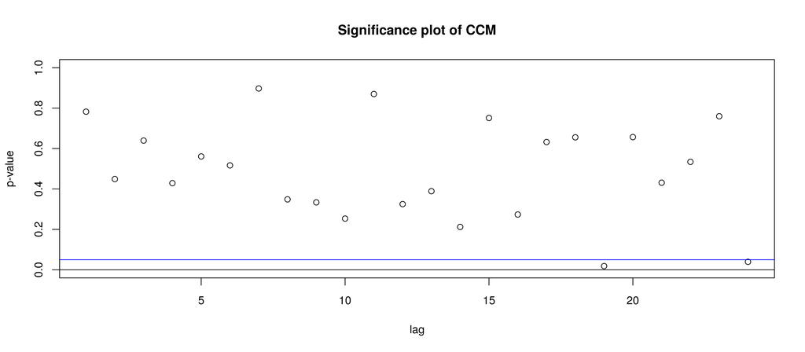

```
Hit Enter to obtain residual plots:
```

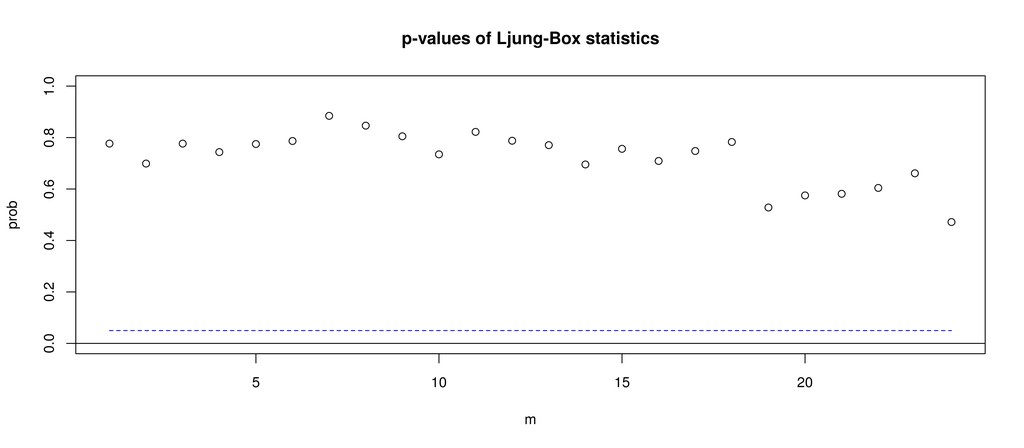

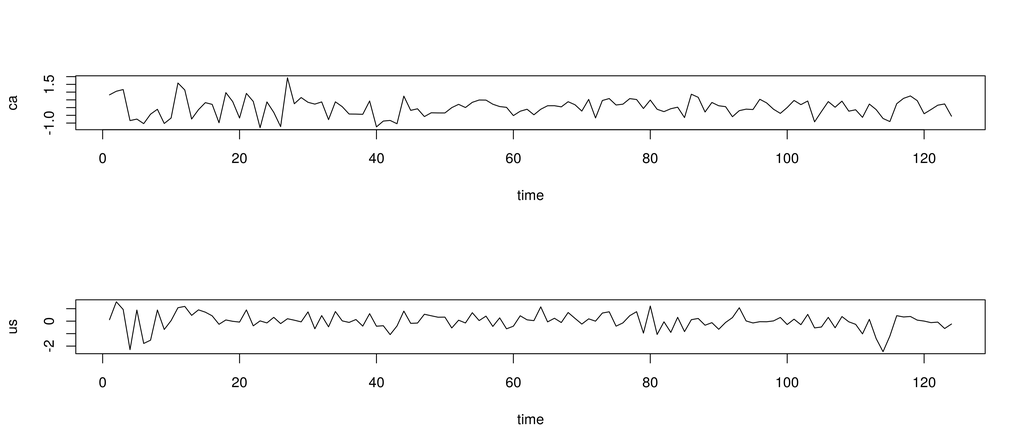

```r
MTSdiag(fit_var1)
```

- One must also check for constant conditional heteroscedasticity and joint distribution of the errors. These tests, and the remedy for them, are outside the scope of our course.